# CIS_544_HW5_Chen

Chen

November 27, 2016

## Problem 1

In this problem, you will use the `randomForest` function from `R`.

- Apply random forests to the `Boston` data using `mtry=6` and using `ntree=25` and `ntree=500`.
- Create a plot displaying the test error resulting from random forests on this data set for a range of values for `mtry` from 4 to 10 with a step of 2, and `ntree` from 25 to 200, with a step-size of 25 (you can use a double-loop for this, for instance).
- Describe the results obtained.

```r
## Load all the libraries which ues in this question.
library(ISLR)
library(MASS)
library(randomForest)
library(tree)
# Create train and test sets
train = sample(1:nrow(Boston), nrow(Boston)/2)
boston.test = Boston[-train ,"medv"]
```

```r
# Out-of-bag error vectors
oob.err = double(13)
# Test error vector
test.err = double(13)
# Run every value of mtry
for (mtry in 1:6) {
    # fit a random forest in the training data with 25 trees
    fit = randomForest(medv ~ ., data = Boston, subset = train,
        mtry = mtry, ntree = 25)
    # Record OOB error
    oob.err[mtry] = fit$mse[25]
    # Calculate predictions
    pred = predict(fit, Boston[-train, ])
    # Record test error
    test.err[mtry] = with(Boston[-train, ], mean((medv - pred)^2))
    # Display the value of mtry
    cat(mtry, " ")
}
```

```
## 1  2  3  4  5  6
```

```r
# Out-of-bag error vectors
oob.err = double(13)
# Test error vector
test.err = double(13)
# Run every value of mtry
for (mtry in 1:6) {
    # fit a random forest in the training data with 500 trees
    fit = randomForest(medv ~ ., data = Boston, subset = train,
        mtry = mtry, ntree = 500)
    # Record OOB error
    oob.err[mtry] = fit$mse[500]
    # Calculate predictions
    pred = predict(fit, Boston[-train, ])
    # Record test error
    test.err[mtry] = with(Boston[-train, ], mean((medv - pred)^2))
    # Display the value of mtry
    cat(mtry, " ")
}
```

```
## 1  2  3  4  5  6
```

## Problem 2

In this problem you will consider the dataset `Carseats` used in the `R` practice session.

We want to predict `Sales` in the `Carseats` dataset using regression trees, treating the response as a *quantitative variable.*

- Split the data set into training and testing sets.

```r
##load the library.
require(ISLR)
require(tree)
```

```r
attach(Carseats)   ##Use the "Carseats" Dataset.
High = ifelse(Sales <= 8, "No", "Yes")   # Create binary response: Sales > 8 means high sales
Carseats = data.frame(Carseats, High)
```

```r
# Create a decision tree: model High as a function of everything but except sales.
tree.carseats = tree(High ~ . - Sales, data = Carseats)
summary(tree.carseats)
```

```
##
## Classification tree:
## tree(formula = High ~ . - Sales, data = Carseats)
## Variables actually used in tree construction:
## [1] "ShelveLoc"   "Price"       "Income"      "CompPrice"   "Population"
## [6] "Advertising" "Age"         "US"
## Number of terminal nodes:  27
## Residual mean deviance:  0.4575 = 170.7 / 373
## Misclassification error rate: 0.09 = 36 / 400
```

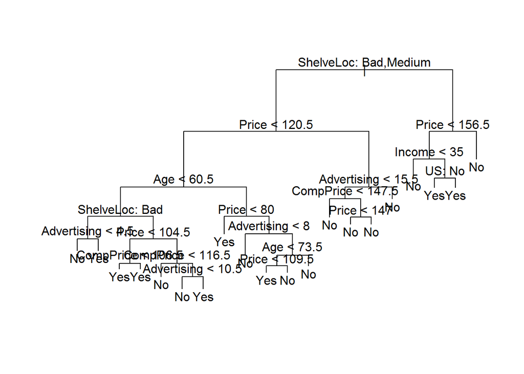

```r
set.seed(1011)  # Make a random number
train = sample(1:nrow(Carseats),250)  # Create train test
tree.carseats = tree(High ~ . - Sales, Carseats, subset = train)   # Create tree using the training set
plot(tree.carseats)  # Plot decision tree
text(tree.carseats,pretty = 0)
```

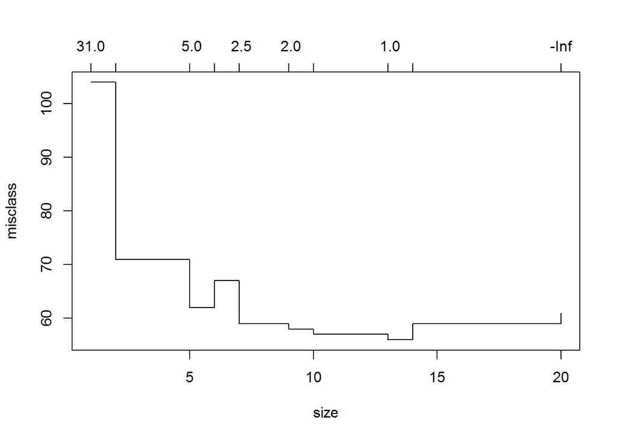

```r
## create and plot the cross validation for the Carseats dicision tree.
cv.carseats = cv.tree(tree.carseats, FUN = prune.misclass)
plot(cv.carseats)
```

```r
# Out-of-bag error vectors
oob.err = double(11)
# Test error vector
test.err = double(11)
# Run every value of mtry
for (mtry in 1:6) {
    # fit a random forest in the training data with 450 trees
    fit = randomForest(Sales ~ ., data = Carseats, subset = train,
        mtry = mtry, ntree = 450)
    # Record OOB error
    oob.err[mtry] = fit$mse[450]
    # Calculate predictions
    pred = predict(fit, Carseats[-train, ])
    # Record test error
    test.err[mtry] = with(Carseats[-train, ], mean((Sales - pred)^2))
    # Display the value of mtry
    cat(mtry, " ")
}
```

```
## 1  2  3  4  5  6
```

## Problem 3

In this problem you will consider the `iris` dataset.

- Build a decision tree to predict the class of flower (Iris Setosa, Iris Versicolor, Iris Virginica), where `Species` is a function of `Sepal.Width` and `Petal.Width`

```r
# load library
library(tree)
# Attach iris data set
attach(iris)
# Print names of variables in the datase
names(iris)
```

```
## [1] "Sepal.Length" "Sepal.Width"  "Petal.Length" "Petal.Width"
## [5] "Species"
```

```r
tree.iris=tree(Species  ~  Sepal.Width  +  Petal.Width,  data = iris)  ## Fit decision tree using function tree() Species as a function of Sepal.Width + Petal.Width
summary(tree.iris)  ## Summary of tree
```

```
##
## Classification tree:
## tree(formula = Species ~ Sepal.Width + Petal.Width, data = iris)
## Number of terminal nodes:  5
## Residual mean deviance:  0.204 = 29.57 / 145
## Misclassification error rate: 0.03333 = 5 / 150
```

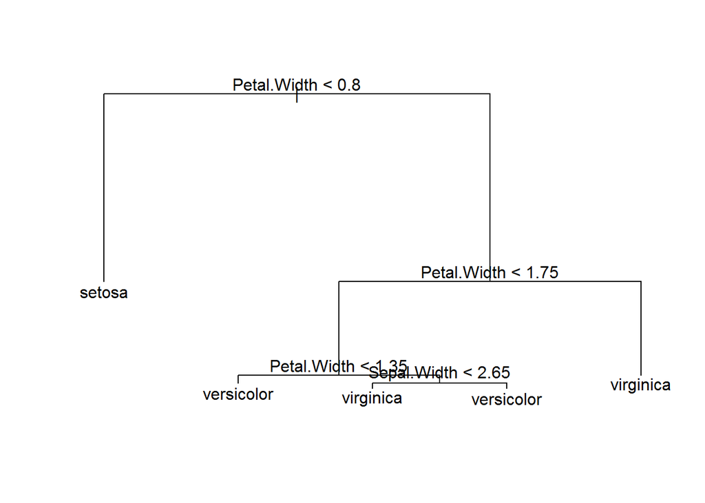

```r
plot(tree.iris)   ## Plot tree
text(tree.iris,pretty(0))
```

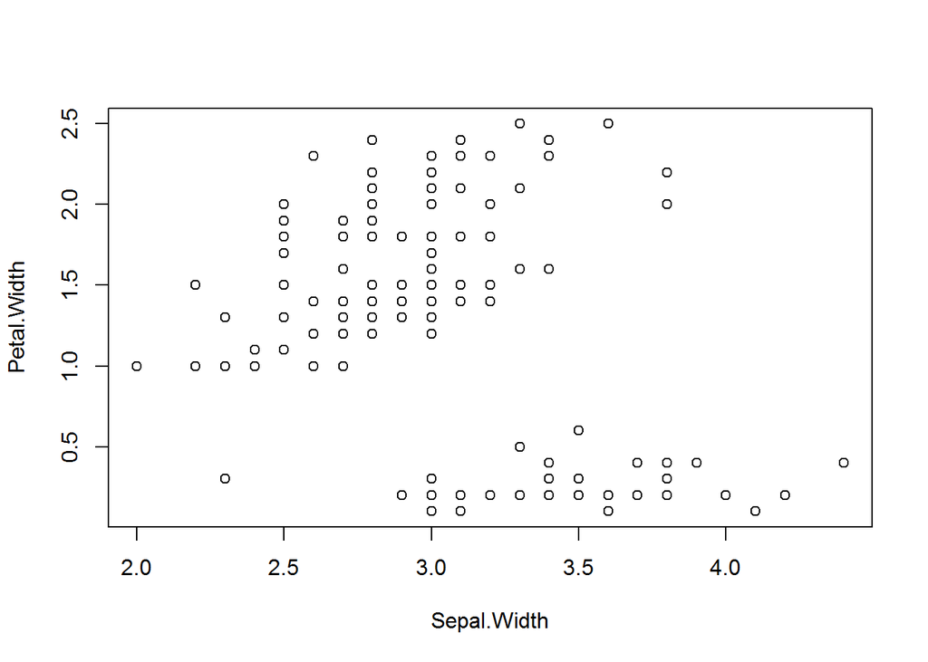

```r
plot(Sepal.Width,Petal.Width)    ## Create a scatter plot of `Sepal.Width` and `Petal.Width`
```

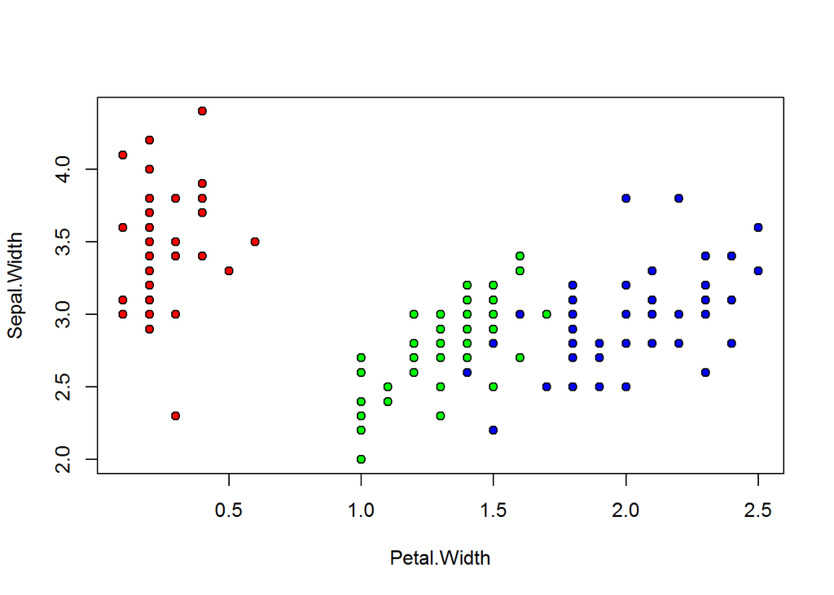

```r
# In order to create a plot with different colors for the
# different classes you can use the command below
plot(Petal.Width, Sepal.Width, pch = 21, bg = c("red", "green",
    "blue")[unclass(Species)])
```

```r
names(iris)
```

```
## [1] "Sepal.Length" "Sepal.Width"  "Petal.Length" "Petal.Width"
## [5] "Species"
```

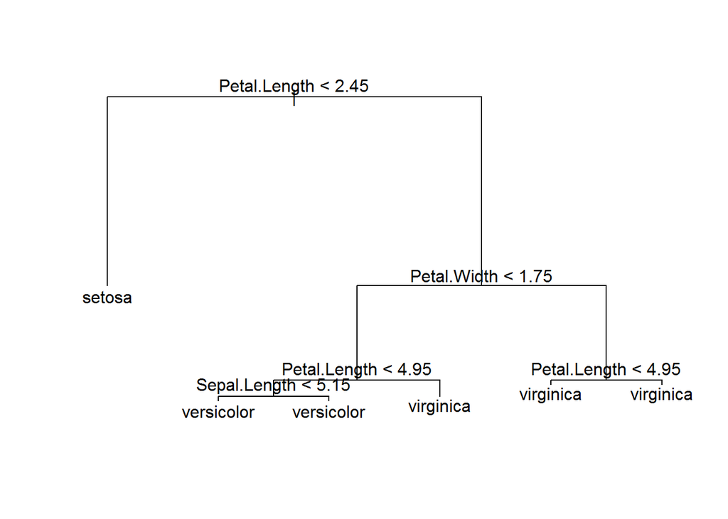

```r
tree.iris=tree(Species  ~  Sepal.Length+ Sepal.Width  +Petal.Length+ Petal.Width,  data = iris)
plot(tree.iris)
text(tree.iris,pretty(0))
```